# Very Basic Spatial Econometrics

Joseph Snitzer

# Introduction

> “Econometrics should be spatial, but not spatial econometrics as it’s been developed.” — [Amine Ouazad](https://twitter.com/amine_ouazad)

For instance, concepts like spatial autocorrelation have a spatial and visual basis that makes the concept more intuitive. There is no need to teach spatial econometrics the same way we teach time series econometrics, which is harder to *see* visually

## Motivation

This is mainly a way to explore how to use RMarkdown to make simple explainers for concepts, hopefully aiding in my own understanding of the concepts.

# Spatial Weights Matrix

We first will consider the fundamental conceptual tool used in spatial econometrics: the spatial weights matrix. Because we are motivated to use spatial econometric tools because we believe there is a degree of correlation to our data, we will need a way to quantify this degree of relation between spatial units. Whereas temporal lags are an obvious way by which to account for temporal autocorrelation in time series models, there is not as clearcut a way to measure spatial relations.  
In the formalized model, we’ll see that there are certain ways to construct a weights matrix that will be more beneficial than others. The *context* of the individual problem will also be informative of which approach makes sense. Below we have visualized only some of the options:

For example, we won’t consider a spatial unit to be a neighbor to itself, for reasons we’ll explore later

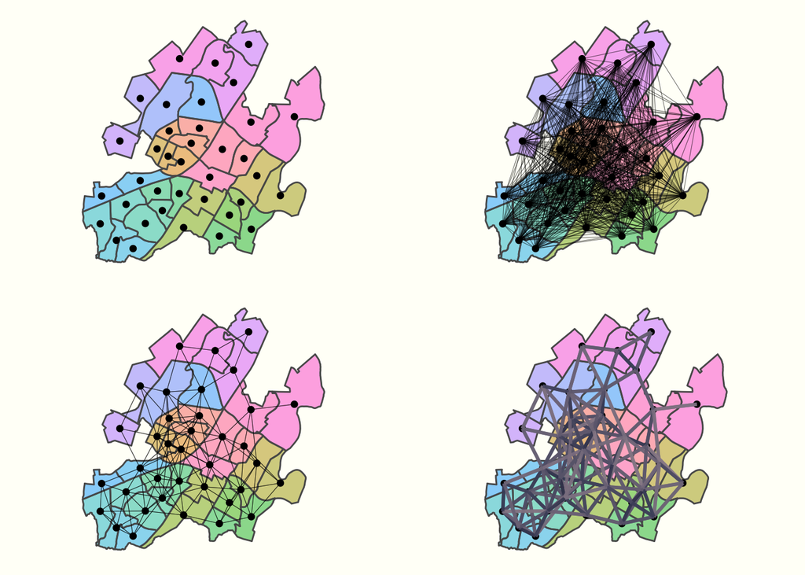

We’ll want to have lower values associated with larger distances. We can accomplish this by calculating the inverse distance instead (where we simply let our zero values remain as zero). Below we’ll see the distance matrix, as well as the inverse matrix.

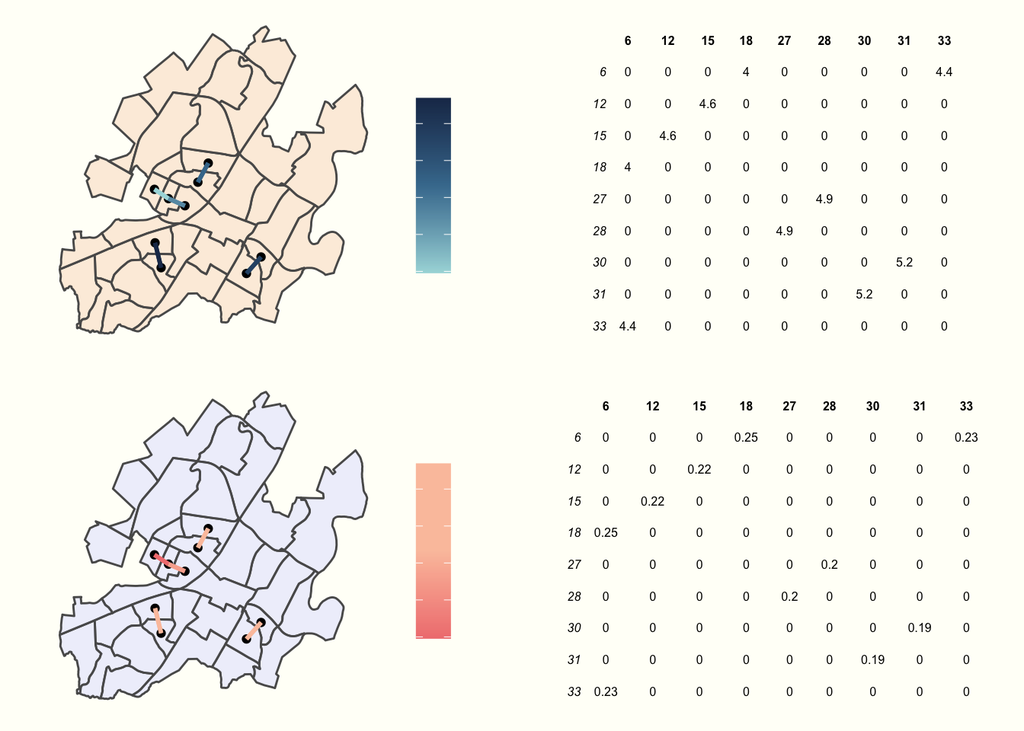

# Spillover effects

Rather than explore spillover effects later on, it might be motivating to be exposed to this concept first before seeing how we can directly quantify some of these concepts.

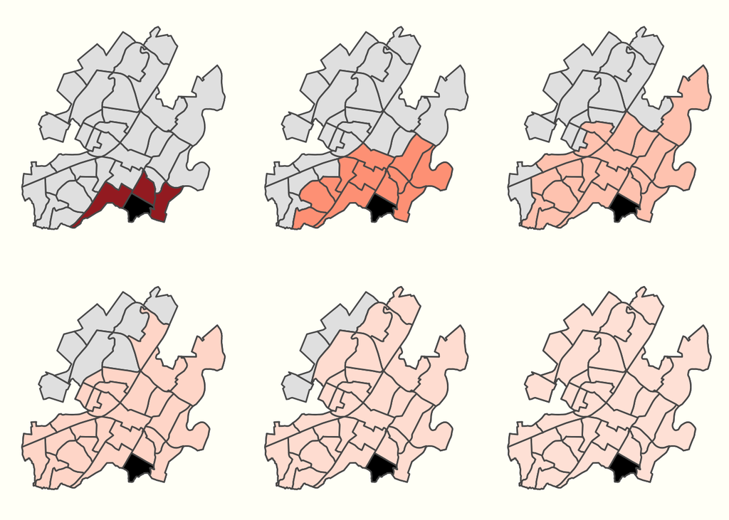

# Spatial econometric model

## Spatial Durbin and its varients

## Revisiting spillover effects